# Red Wine EDA by Bhargava

### Alcohol and Sulphates

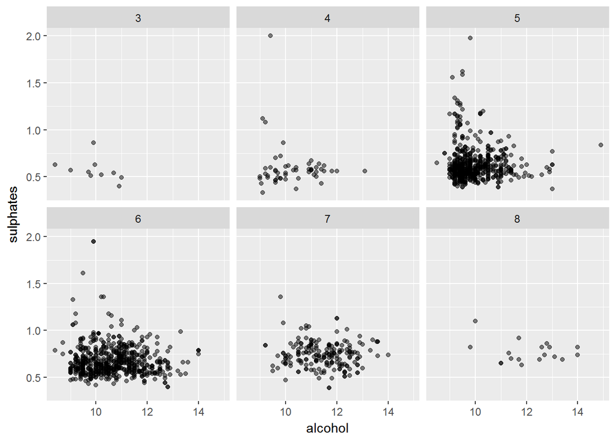

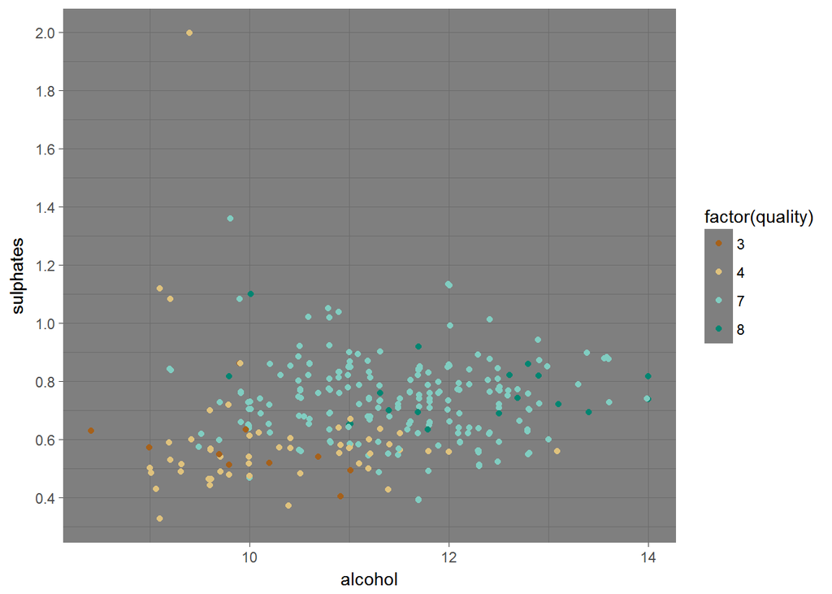

[figure not shown]

I was expecting this plot to be like the citric acid and alcohol one,But i was amazed to see that nearly all wine lie below 1.0 sulphates level except quality 5.

Because of overploting i have removed the the rating B from next plot to visualize the trends more deeply.We can see rating A wines mostly have sulphates values between 0.5 and 1 and the best wine quality 8 have sulphate values between 0.6 and 1.Alcohol has the same values as seen before

Most C rating wines have sulphate value below 0.6

From the sulphates vs.alcohol plot which was coloured by quality we can observe that best quality redwines tend to have high concentrations of sulphates and alcohol% .

# Multivariate Analysis

### Talk about some of the relationships you observed in this part of the investigation. Were there features that strengthened each other in terms of looking at your feature(s) of interest?

I am quite optimistic that higher citric.acid and lower volatile.acidity contribute towards better wines. Also, better wines tend to have higher alcohol content

### Were there any interesting or surprising interactions between features?

Yes, I was little surpised with suplhates and alcohol graphs . Sulphates had a better correlation with quality than citric acid still the distribution was not that distinct between the different quality wines.Further nearly all wines had a sulphuate contant of less than One . Irrespective of alcohol content.Even though suplhate is a biproduct of fermantation just like alcohol . So longer fermantation should have produced more sulphates and alcohol which is clearly not the case.

# Final Plots and Summary

### Plot One

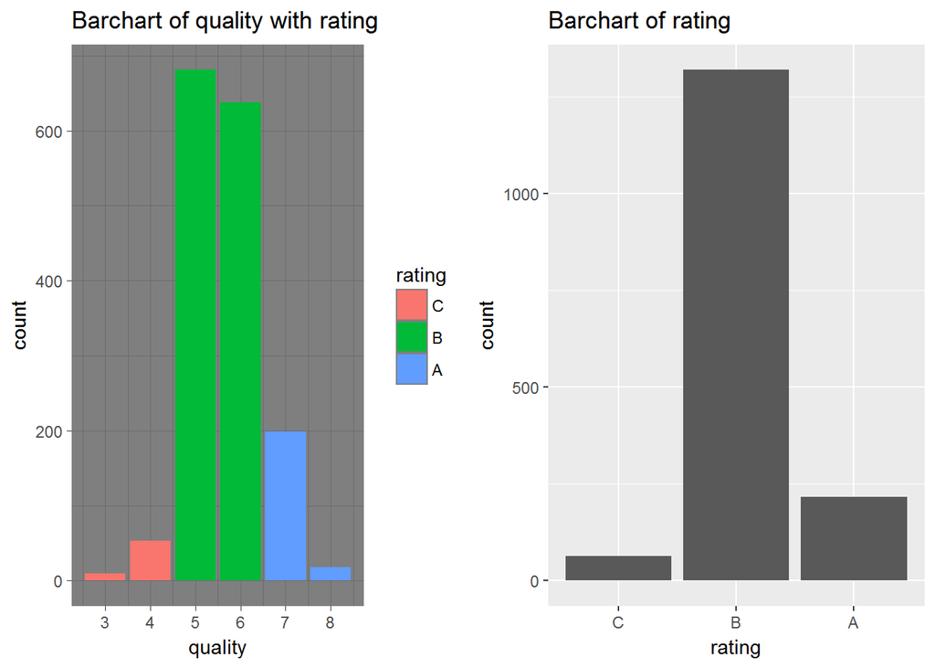

### Description One

The plot is from univarent section.The first plot which introduced the idea of this analysis.I believe it is an important plot as it was the one which was one of the main driving idea behind his whole analysis into quality of red wine

Lets break this distribution for one final time an look at the percentage

By rating

A rated=13.5% wines

B rated=82.48% wines

C rated=3.9% wines

### Plot Two

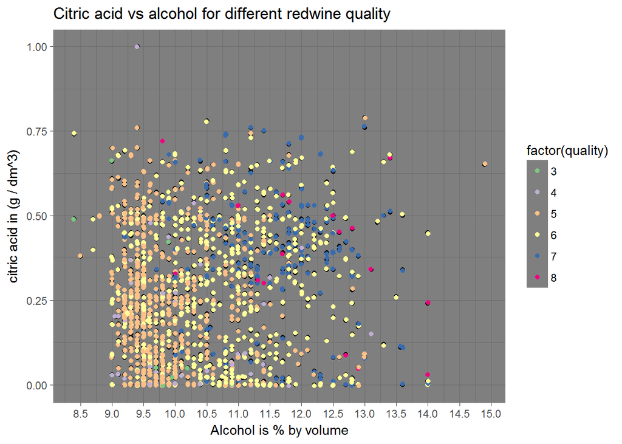

### Description Two

The plot is from multivarent section discussing the relation of alcohol and citric acid concentration on quality

### Plot Three

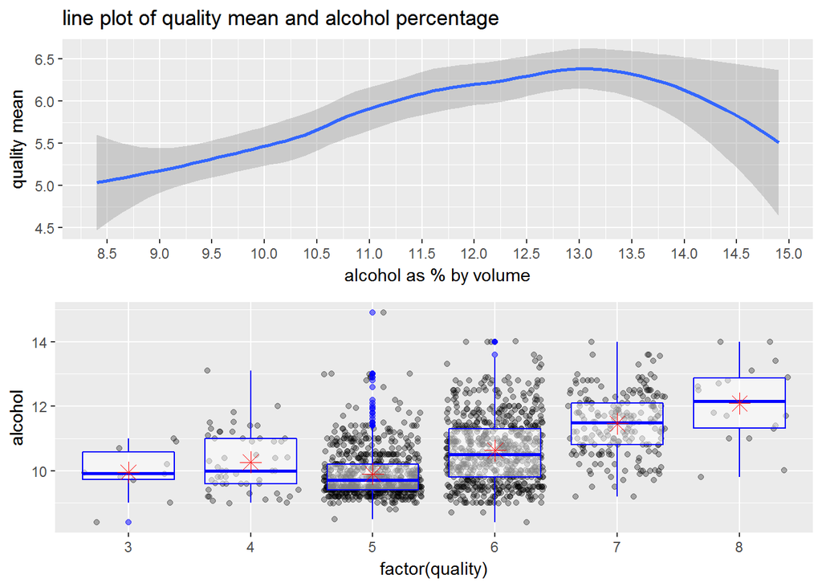

### Description Three

Plots taken from bivarate analysis section discussing about effect of alcohol percentage on quality

The above boxplots show a peroidic rise in level of alcohol.One of the interesting findings i came across arised from this quality mean and alcohol% graph. An interesting trend of a exponetial decrement above 13% alcohol gave way to futher analysis which show that the alcohol which had a positive correlation of 0.47 becomes negatively correlated above 13%

This behaviour led to two seperate findings about alcohol in relation with quality

Below 13 % - Alcohol has a positive correlation of 0.47 the heighest correlation on positive side with quality of red wine.The boxplots also show an increase in median alcohol % with increase in quality

# Reflection

The red wine dataset contains 1,599 observation with 13 variables of which 11 were on the chemical properties and 1 was for numbering and one for quality. I was interested in the correlation between the features and wine quality.I also created a new variable rating which had values from A for 8-7 ,B for 6-5 and C for 4-3

Unlike the diamond case study,the wine quality is more complex. Most of the data visualization in this project was done on the 4 features that have the highest correlation coefficient: alcohol(0.476), volatile acidity(-0.391), sulphates(0.251),citric acid(0.226).

Most helping was the correlation matrix which i was able to make with ggcorr function.I helped to figure out the correlations between other variables too.Although I was unable to do as much intervariable analysis because so many of the variables were numeric instead of factoral.In the latter anaylis is grouped quality as a factor for bringing out important observations

I noticed that the dataset is highly unbalanced. It has many data points for medium quality wine (5, 6). However, for low quality ( 3,4 ) and high quality (7, 8) wine, it has fewer data points.The data set for medium quality wine covered above 80% of the distribution

If the data set has more records on both the low end and high end, the quality of analysis can be improved. We can be more certain about whether there is a significant correlation between a chemical component and the wine quality.

I would also like to see the data about temperature ,region of wine making, Quality of grapes used for making wine.These thinks will help in expanding my research further